# Beyond Boundaries — what do the Xenium multimodal segmentation stains add to the transcriptome?

<sub>`results/08_image_only_prediction/anatomy_lesion_prediction.png`</sub>

**Lesion maps from images alone** (held-out animals; AUROC 0.90, transcriptome composition 0.92, both 0.93):

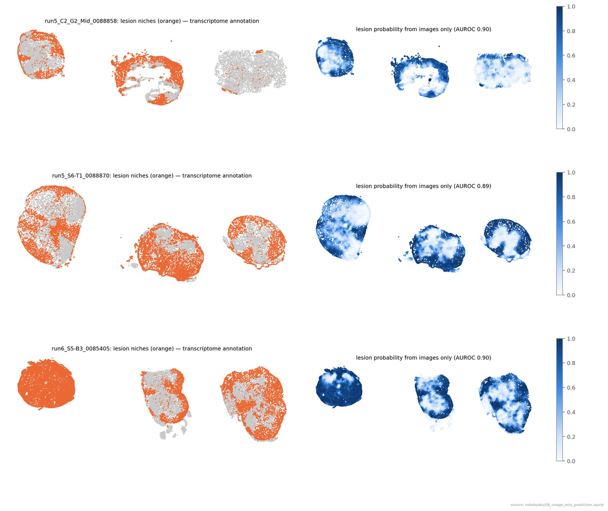

<sub>`results/08_image_only_prediction/lesion_maps_images_vs_annotation.png`</sub>

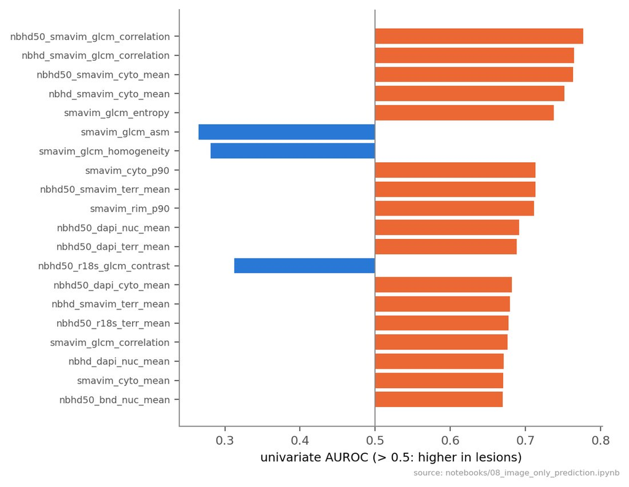

<sub>`results/08_image_only_prediction/lesion_top_image_features.png`</sub>

Animal metadata — images track score and chronic timepoint but stay below the transcriptome; they identify the **imaging run** perfectly (strong batch signature — important for adding runs 1–3):

| task | input metric | images | transcriptome | both |
| --- | --- | --- | --- | --- |
| clinical score (all) | Spearman ρ (per animal) | 0.62 | 0.79 | 0.76 |
| day of sacrifice (chronic) | Spearman ρ (per animal) | 0.52 | 0.84 | 0.75 |
| day of sacrifice (relapse-remitting) | Spearman ρ (per animal) | -0.57 | 0.03 | -0.36 |
| phase (chronic: pre/onset · peak · chronic) | accuracy (per animal) | 0.56 | 1.00 | 0.94 |
| phase (RR: peak · remission) | accuracy (per animal) | 0.44 | 0.78 | 0.44 |
| sex (chronic) | accuracy (per animal) | 0.25 | 0.38 | 0.25 |
| run5 vs run6 (RR) — batch control | accuracy (per animal) | 1.00 | 0.44 | 0.89 |
| model: chronic vs RR — confounded with slide/sex/level | accuracy (per animal) | 0.72 | 0.96 | 0.76 |

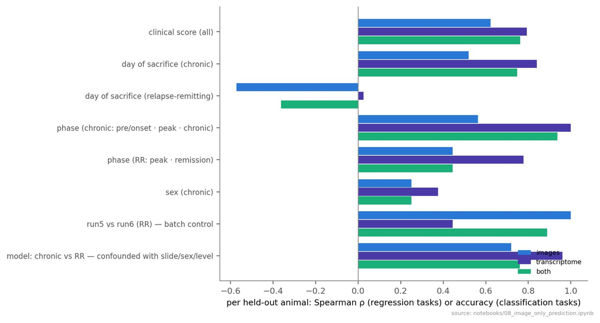

<sub>`results/08_image_only_prediction/animal_metadata_prediction.png`</sub>

## Caveats

- CD45 component undetectable → no immune-membrane readout from ch1.
- αSMA and vimentin share a channel; 18S drew ~95 % of masks (18S distribution features partly by construction).
- Lesion niches are transcriptome-defined, favouring the transcriptome in lesion comparisons.
- 25 animals; only 2 CFA control pieces in runs 5/6 (runs 1–3 were added later, notebooks 10–19).

## Next steps

1. Validate the 18S-texture severity marker on runs 1–3 done (notebook 13): partly replicated.
2. Disentangle vimentin vs αSMA: post-Xenium immunofluorescence with separate antibodies (see the verdict document).
3. Perivascular T-cell 18S polarity withdrawn (notebook 19).
4. Use the neuropil-loss index and 18S per cell as covariates in the RRMAP2 lesion analyses.
5. Runs 1–3: image features carry a strong run signature — compare within run / batch-correct before pooling.